# Assignment 3: Market Report Chicago

Clara Fong

5/25/2021

# The Assignment Description

Generate a market report for one Chicago community area using at least three measures. Your market report should have some theme, like a suite of health or transportation measures. Examples of measures could include accessibility to playgrounds, parks, or grocery stores, or rates of poverty, cancer, or income statistics.

- At least 1 measure should have a more sophisticated spatial analytic technique used for implementation. This will likely be a measure of some resource access. This could be a point-in-polygon (PIP) operation, buffer analysis (count of buffers or union of buffers showing coverage), density surface, etc.
- Additional measures can be visualized as points, lines, choropleth mapping, etc. (Choropleth mapping by itself is not considered the advanced analytic technique required for at least one measure.)
- You can include as many maps as you need to for your final report: this may be 1 map with all measures shown, 3 maps each highlighting a different variable, etc.
- You must include a summary of your market analysis, including (1) overview of your market and why you chose your measures, (2) description of data including source citations, (3) description of methods used to represent each measure, (4) a cohesive presentation and (5) discussion of the results. You should definitely note how different indicators for your community area exist in relation to its neighboring community areas. The summary can be brief (2-3 paragraphs) but must include the above.

It is recommended that you calculate measures for the entire dataset of Chicago community areas, and then zoom into to your area of interest. If there is no visualization/analysis/discussion of how resources or statistics vary between neighboring areas, you will not receive full credit.

# Theme: Affordable housing and outdoor spaces

I was interested in looking at the kinds of outdoor amenities/spaces in areas with high levels of afforable housing units. My initial thinking is that there might be a difference in terms of sheer numbers of outdoor spaces (e.g., parks, playgrounds, etc.) in communities with higher affordable housing units, but also taking into account the “accessibility” by distance of these spaces Specficially, I want to know whether park areas have a wide set of amenities overlap with community areas that have a high number of affordable housing units.

## Summary of Maps

Given the variability in the data types and the scope of what we’ve learned in class, I have made three maps with some variation merging these three data sources together. It follows:

1. **Afforable housing points**: transforming the csv data to point data to map the units of affordable housing, then using a point-in-polygon operation to count the number of affordable housing units in a given community boundary
2. **Park areas and amenities**: plotting a chloropleth map of levels of amentities (specifically, I used variables that indicated a park had a playground, which is already counted by community area in the data)
3. **Dog parks points**: there aren’t a lot of dog parks, but I wanted to identify where they were relative to the areas with large numbers of playgrounds

# Understanding Affordable Housing

## Mapping Units of Affordable Housing as Points

The first step for the PIP operation was to convert the csv affordable housing data into spatial data. After cleaning for that, I created an initial plot to look at the pattern of affordable housing units in Chicago

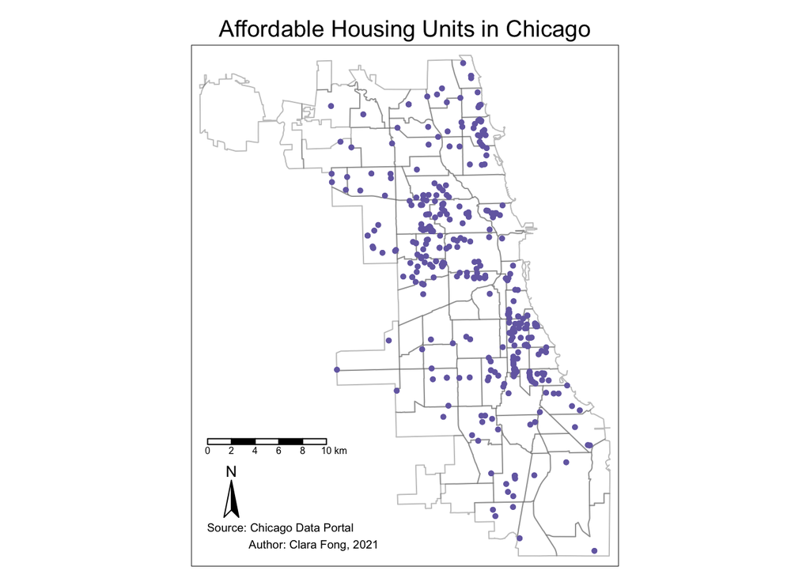

## Mapping Affordable Housing after PIP Operation

After counting the number of affordable housing units by each community area, the simplest way to summarize this spatial pattern, I plotted a chrolopleth map below.

```r
#spatial join
housing_in_boundaries <- st_join(housing_pts, boundaries, join = st_within)

#count crimes per tract
housing_pip <- housing_in_boundaries %>%
  group_by(community) %>%
  count() %>%
  rename(afford_house_ct = n)

#removing geometry from previous df
housing_pip <- as.data.frame(housing_pip) %>%
    select(community, afford_house_ct)

#merge to main df
housing.parks.df <- merge(boundaries, housing_pip, by="community")
```

[interactive chart not shown]

The map has 6 unique bins, and it was evident from this plot that there are three community areas on the West and South side (Humbolt Park, North Lawndale, and Grand Boulevard) that have the highest number of afforable housing units compared to the rest of Chicago. Moving forward I will focus on **one of these three areas** and plot the difference in park numbers compared to neighboring peers.

# Park Amenitities by Playground Availability

Similar to the chrolopleth map above, I want to look at the number of playgroudns in Chicago parks. However, since the point-in-polygon operation is already done for this dataset (that is, they already count the number of playgrounds without providing coordinate locations of each playground), I will be creating the chrolopleth map based on existing data provided.